# Lesson 16: Describing Categorical Data (Proportions)

Preparation

- Word Document
- PDF Document

## Solutions

**Please note that the steps show rounded numbers, but that the final answers to the problems are calculated without rounding.**

Problem

Part

Solution

1

-

b. Pie Charts  
d. Bar Charts

2

-

$\hat{p} = \frac{x}{n}$  
n = total sample size  
x = number of individuals in sample with the characteristic you are focusing on.

3

-

P or the population proportion

4

-

$\text{Standard Deviation of } \hat{p} = \sqrt{\frac{p(1-p)}{n}}$  
n = total sample size  
p = the true population proportion, which is also the mean of the distribution of $\hat{p}$

5

-

Answers may vary: Categorical data groups the individuals in your study into categories, while numerical data assigns numbers to the individuals in your study. These numbers are a subset of the real numbers and can be discrete or continuous.

6

-

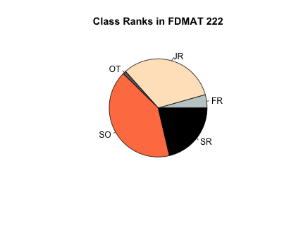

7

-

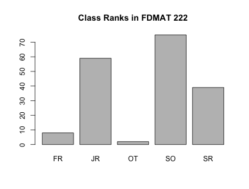

8

-

Your answers could vary. You could’ve used proportions to describe the data, described the data in words, or displayed a frequency table.  
**Freshman**: Count=8, $\hat{p}$=0.0437  
**Sophmore**: Count=75, $\hat{p}$=0.4098  
**Junior**: Count=59, $\hat{p}$=0.3224  
**Senior**: Count=39, $\hat{p}$=0.2131  
**Other**: Count=2, $\hat{p}$=0.0109

9

A

The mean is 7% or 0.07 in this sample and the standard deviation is 0.0093

9

B

z= 1.073

9

C

Area = 0.1416